# LBB - Unveiling Socio Demographic Patterns: Exploring Data Panels with plm() in R

Data Panels with plm() in R

Heinz Metrosan Donradt S

02 March, 2024

## 0.1 Setup Library/Package

*Package* adalah kumpulan fungsi R, data, dan kode yang dikompilasi dalam format yang terdefinisi dengan baik. Direktori tempat penyimpanan paket disebut library.

Untuk dapat mengikuti materi ini, peserta diharapkan sudah menginstall beberapa packages di bawah ini. Apabila package tersebut belum terinstall, silahkan melakukan instalasi package dengan copy dan jalankan code berikut pada bagian *console*

> install.packages(c(“knitr”, “rmarkdown”, “dplyr”,“tidyr”,“lubridate”, “ggcorplot”, “ggplot2”, “gplots”, “foreign”, “plotly”,“plm”,“lfe”,“lmtest”,“car”,“tseries”,“MLmetrics”))

Apabila package sudah terinstall, silahkan jalankan code dibawah ini untuk mengaktifkan package-package yang akan digunakan pada materi ini.

```r
#Packages untuk pengolahan dataframe
library(dplyr)
library(tidyr)
library(lubridate)

#Packages untuk membuat visualisasi
library(ggcorrplot)
library(gplots)
library(ggplot2)
library(plotly)
library(foreign)

#Packages untuk melakukan analisis
library(plm)
library(lfe)
library(lmtest)
library(car)
library(tseries)
library(MLmetrics)
```

# 1 Data Panel

contoh data panel”

- Tingkat pengangguran tahunan setiap negara bagian selama beberapa tahun
- Penjualan triwulanan masing-masing toko selama beberapa kuartal

**1. Keuntungan Data Panel**

Data panel yang menggabungkan data data cross section dan time series, memiliki beberapa keunggulan dibandingkan data cross-sectional saja atau data deret waktu saja, antara lain:

- Mendapatkan sampel yang besar sehingga lebih banyak informasi dan lebih sedikit multikolinieritas di antara variabel-variabel sehingga meningkatkan efisiensi estimasi ekonometrika
- Model yang dapat diinterpretasikan, kita dapat menginterpretasikan koefisien regresi dalam kerangka efek cross-section dan time-series.

**2. Struktur Data Panel**

Data panel memiliki tiga jenis data, yaitu cross section, pooled cross section, dan panel.

- **Cross Section Data**

Data cross sectional adalah jenis data yang dikumpulkan dengan mengamati banyak subjek pada satu titik atau periode waktu.

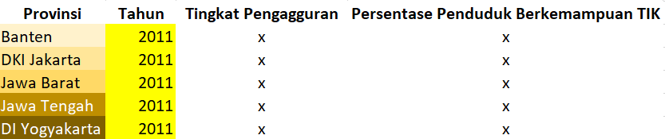

- **Pooled Cross Section Data**

Pooled Cross sectional adalah jenis data yang mengamati satu subjek pada banyak titik atau periode waktu.

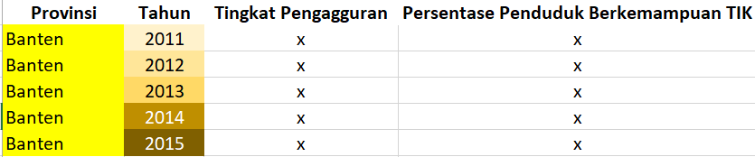

- **Panel Data**

Panel data adalah jenis data yang mengamati banyak subjek pada banyak titik atau periode waktu.

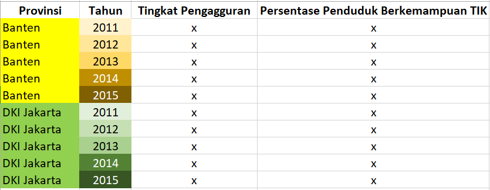

- **Balance - Unbalanced Panel Data**

Jika jumlah unit waktu sama untuk setiap individu, maka data disebut *balanced panel*. Jika sebaliknya, yakni jumlah unit waktu berbeda untuk setiap individu, maka disebut *unbalanced panel*

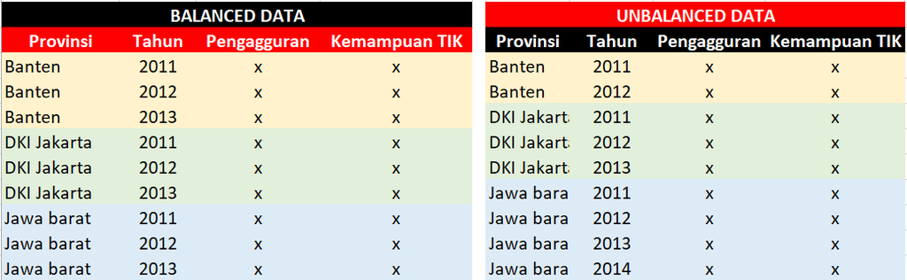

**3. Model Data Panel**

Jika kita memiliki **T** periode waktu (t = 1, 2, …, T) dan **N** jumlah individu (i = 1, 2, …, N), maka dengan data panel kita akan memiliki total unit observasi sebanyak **NT**.

$$y_{it} = \beta_0+\beta
_{1t}*x_{1t}+u_{it}$$
Dimana:

- $y_{it}$ adalah variabel target
- indeks $i$ mendefiniskan individu, wilayah, kota, perlakuan dll.
- indeks $t$ mendefinisikan waktu.
- $\beta_0$ adalah intercept
- $\beta _{1t}*x_{1t}$ adalah koefisien untuk variabel prediktor 1
- $u_{it}$ adalah disturbance

berdasarkan model tersebut indeks `i` menjadi dimensi untuk cross sectional dan indeks `t` menjadi dimensi untuk deret waktu. Sedangkan $u_{it}$ adalah nilai yang menunjukkan heterogenitas antar cross sectional dan deret waktu di dalam mode, yang didefinisikan sebagai berikut:

$$u_{it} = \mu _i+\lambda _t+\upsilon
_{it}$$
dimana:

- $\mu _i$ : mewakili heterogenitas individu (cross section) yang tidak dapat diamati
- $\lambda _t$ : menunjukkan heterogenitas waktu yang tidak dapat diamati
- $\upsilon _{it}$ : merupakan nilai error sisaan

Dua komponen pertama $\mu _i$ dan $\lambda _t$ disebut juga sebagai *within component* sedangkan komponen terakhir $\upsilon _{it}$ merupakan *panel or between component*

## 1.1 Pemodelan

Terdapat tiga pendekatan yang digunakan dalam model panel yaitu *Common/ Polled Effects*, *Fixed Effects* dan *Random Effects*.

**1. Model Common/ Pooled Effects (CEM)**

Model gabungan atau common effect model (CEM) atau pooled least square (PLS) merupakan pendekatan model data panel yang sederhana karena mengkombinasikan data time series dan cross section, tanpa memperhatikan pengaruh spesifik waktu maupun individu. Koefisien regresi (intersep ataupun kemiringan) diasumsikan konstan antar individu dan waktu. Metode ini bisa menggunakan pendekatan ordinary least square (OLS) atau metode kuadrat terkecil (MKT) untuk mengestimasi model data panel. Untuk membuat model CEM di R dapat menggunakan fungsi `plm()` dari package plm dengan parameter sebagai berikut:

- `formula` = Target ~ Prediktor
- `data` = berupa dataframe
- `index` = c(“kolom_individu”,“kolom_waktu”)
- `model` = “pooling”

**2. Fixed Effects**

- `formula` = Target ~ Prediktor
- `data` = berupa dataframe
- `index` = c(“kolom_individu”,“kolom_waktu”)
- `model` = “within”

**3. Random Effects**

- `formula` = Target ~ Prediktor
- `data` = berupa dataframe
- `index` = c(“kolom_individu”,“kolom_waktu”)
- `model` = “random”

## 1.2 Pemilihan Model Terbaik

Untuk memilih model mana yang terbaik dari ketiga model diatas, perlu dilakukan pengujian hipotesis berikut ini:

**Uji Chow**

Menurut Ghozali dan Ratmono (2013), uji chow digunakan untuk memilih pendekatan yang lebih baik antara model gabungan dengan model pengaruh tetap. Untuk melakukan uji Chow dapat menggunakan fungsi `pooltest(model_cem, model_fem)`, dengan hipotesis yang diujikan adalah sebagai berikut.

- H0 : Model gabungan
- H1 : Model pengaruh tetap

Keputusan tolak H0 (model pengaruh tetap terpilih) apabila nilai p-value < α.

**Uji Hausman**

- H0 : Model pengaruh acak
- H1 : Model pengaruh tetap

Keputusan tolak H0 (model pengaruh tetap terpilih) apabila nilai p-value < α.

**Pengujian Lanjutan**

Apabila **model gabungan** atau **model pengaruh acak** yang terpilih sebagai model terbaik, perlu dilakukan uji lanjutan untuk memeriksa apakah model dipengaruhi oleh individu/waktu/individu & waktu. Untuk memeriksa pengaruh tersebut digunakan **Uji Lagrange Multiplier**.

Di R untuk melakukan Uji Lagrange Multiplier dapat dilakukan dengan menggunakan fungsi `plmtest()` dari package `plm` dengan parameter:

- x = model terpilih
- type = `"bp"` , menggunakan Breusch Pagan test
- effect =
  - `"time"` : untuk menguji pengaruh waktu
  - `"individual"` : untuk menguji pengaruh individu
  - `"twoways"` : untuk menguji pengaruh individu & waktu

berikut hipotesis pengujian untuk pemeriksaan setiap pengaruh:

**Pemeriksaan Pengaruh Individu & Waktu**

Hipotesis yang diuji adalah sebagai berikut.

- H0 : Tidak ada pengaruh individu & waktu
- H1 : Ada pengaruh individu & waktu

**Pemeriksaan Pengaruh Individu**

Hipotesis yang diuji adalah sebagai berikut.

- H0 : Tidak ada pengaruh individu
- H1 : Ada pengaruh individu

**Pemeriksaan Pengaruh Waktu**

Hipotesis yang diuji adalah sebagai berikut.

- H0 : Tidak ada pengaruh waktu
- H1 : Ada pengaruh waktu

dengan ketentuan untuk ketiga hipotesis adalah H0 ditolak jika P-value < α. Dimana nilai α yang umum digunakan adalah sebesar 5%.

## 1.3 Pengujian Asumsi

dikarenakan analisis data panel menggunakan konsep regresi dan time series maka ada beberapa Asumsi yang perlu dipenuhi sebagai berikut:

Asumsi model linear regression:

1. No Multicollinearity (VIF)
2. Normality of Residuals
3. Homogenitas of Residuals

Asumsi Time Series:

1. No Autocorelation

**Note**: Pengujian Asumsi hanya perlu dilakukan untuk model yang akan digunakan

**1. Pemeriksaan Multikolinieritas**

Multicollinearity adalah kondisi adanya **korelasi antar prediktor yang kuat**. Hal ini tidak diinginkan karena menandakan prediktor redundan pada model, yang seharusnya dapat dipilih salah satu saja dari variable yang hubungannya amat kuat tersebut. Harapannya **tidak terjadi multicollinearity**. Pemeriksaan Multikolinieritas bisa dilakukan dengan menggunakan fungsi fungsi `vif()`, dengan ketentuan

- nilai VIF > 10: terjadi multicollinearity pada model
- nilai VIF < 10: tidak terjadi multicollinearity pada model

**Note**: Pemeriksaan asumsi multikolinieritas bisa dilakukan diawal sebelum dilakukan pemodelan data panel, dengan cara terlebih dahulu dilakukan pembuatan model regresi dengan fungsi `lm()` dan akan diujikan menggunakan fungsi `vif()`.

**2. Pengujian Asumsi Normalitas Residual**

Model diharapkan menghasilkan **error yang berdistribusi normal**. Dengan begitu, error lebih banyak berkumpul di sekitar angka nol. Pengujian asumsi normalitas di R dapat dilakukan dengan menggunakan fungsi `shapiro.test()`. dengan hipotesis yang diujikan adalah sebagai berikut.

- H0 : Sisaan berdistribusi normal
- H1 : Sisaan tidak berdistribusi normal

dengan ketentuan H0 ditolak jika P-value < α. Dimana nilai α yang umum digunakan adalah sebesar 5%.

**3. Pengujian Asumsi Homogenitas Residual**

Diharapkan error yang dihasilkan oleh model menyebar secara acak atau dapat dikatakan **variasi konstan**. Pengujian asumsi Homogenitas di R dapat dilakukan dengan menggunakan fungsi `bptest()`, dengan hipotesis yang diujikan adalah sebagai berikut.

- H0 : Sisaan memiliki ragam homogen
- H1 : Sisaan tidak memiliki ragam homogen

dengan ketentuan H0 ditolak jika P-value < α. Dimana nilai α yang umum digunakan adalah sebesar 5%.

**4. Pengujian Asumsi Autokorelasi**

Untuk mengecek ada/tidaknya bisa menggunakan uji Ljung-box dengan menggunakan fungsi `Box.test(residual model, type = "Ljung-Box)`, dengan hipotesis yang diujikan adalah sebagai berikut.

- H0 : tidak terjadi autokorelasi pada sisaan
- H1 : terjadi autokorelasi pada sisaan

dengan ketentuan H0 ditolak jika P-value < α. Dimana nilai α yang umum digunakan adalah sebesar 5%.

## 1.4 Alur Kerja Data Panel

Analisis data panel di R dapat dilakukan dengan mengikuti alur kerja berikut ini:

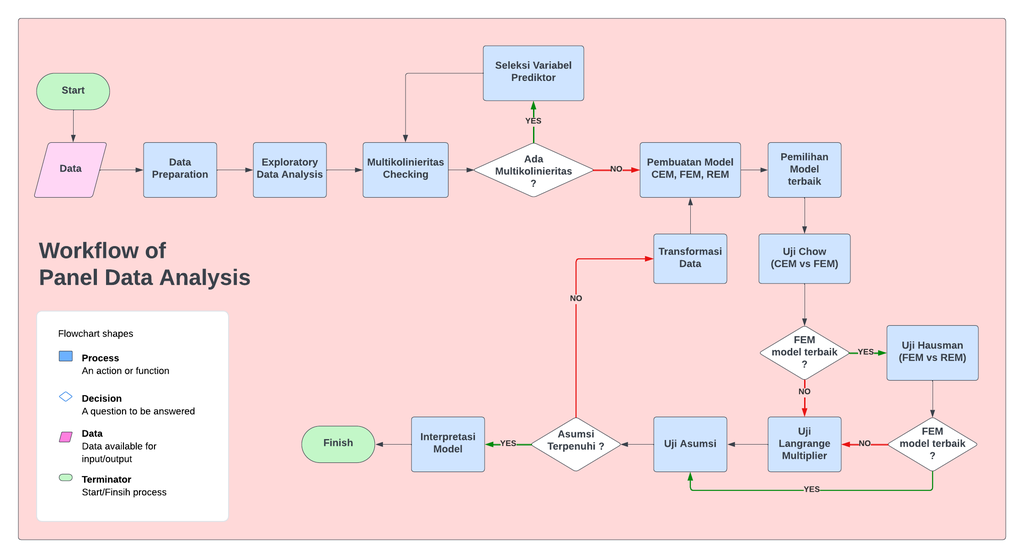